# CS18_experiment1_analysis

Jeanne

December 2, 2018

# Experiment 1: Learning task

In this task, participants saw two pictures on the screen and heard one word. Their task was to indicate which picture the word matched with using a button pad. THey would get feedback on their answer (the correct picture staid on the screen while the incorrect one disappeared, sometimes replaced by the word’s spelling).

```r
##reading the learning task data
exp1_training <- read.csv("Experiment1_training_masterFile.csv", header=T)

##excluding subjects who performed poorly (on training and/or on the picture matching task. Bases for exclusion described below and in paper)

exp1_training.sub<-exp1_training[!exp1_training$ID %in% c("CN01","CN02","CN05","CN10","CN19","CN21","CN26","CN28","CN29",
                                         "VN06","VN08","VN23",
                                         "CV02","CV04","CV10","CV12","CV14","CV21","CV22"),]

#length(exp1_training.sub$RT) = 38400

##eliminating trials that were too fast (i.e. <250 ms)
exp1_training.sub250 <- exp1_training.sub[exp1_training.sub$RT>250,]

#length(exp1_training.sub250$RT) = 37438
## --> eliminating trials faster than 250ms resulted in excuding about 2.5% of the data
```

The paradigm used for the learning task is similar to the one used in Leach & Samuel 2007 and Samuel & Larraza 2015. Like in these two papers, subjects learned the word-picture pairs after about 10 repetitions.  
The repetition variable corresponds to number of time a particular picture-word pair was presented.Each was presented a total of 20 times.

#### Means:

```r
exp1_training.mean <- aggregate(accuracy ~ block+repetition, exp1_training.sub250, FUN="mean")
exp1_training.mean
```

```
##    block repetition accuracy
## 1     B1          1     0.64
## 2     B1          2     0.67
## 3     B1          3     0.77
## 4     B1          4     0.82
## 5     B1          5     0.86
## 6     B1          6     0.87
## 7     B1          7     0.88
## 8     B2          8     0.91
## 9     B2          9     0.89
## 10    B2         10     0.90
## 11    B2         11     0.89
## 12    B2         12     0.92
## 13    B2         13     0.92
## 14    B2         14     0.92
## 15    B3         15     0.94
## 16    B3         16     0.94
## 17    B3         17     0.93
## 18    B3         18     0.93
## 19    B3         19     0.92
## 20    B3         20     0.94
```

#### Plot:

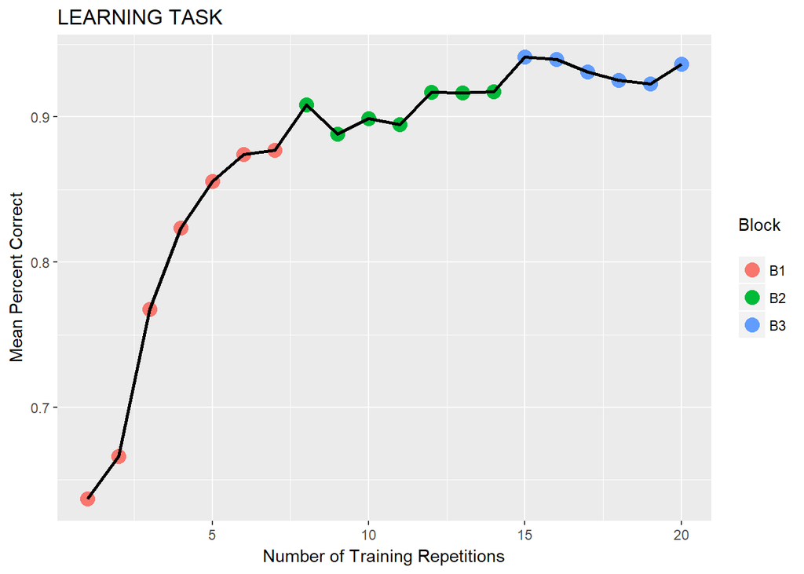

By the end of the learning task, subjects were at ceiling.

# Experiment 1: Picture Matching task

```r
##reading Picture matching task data
exp1_data<-read.csv("Experiment1_masterFile.csv", header=T)
str(exp1_data)
```

```
## 'data.frame':    10112 obs. of  13 variables:
##  $ ID                 : Factor w/ 79 levels "CN01","CN02",..: 1 1 1 1 1 1 1 1 1 1 ...
##  $ group              : Factor w/ 3 levels "Canonical_None",..: 1 1 1 1 1 1 1 1 1 1 ...
##  $ item.number        : int  99 124 110 96 98 125 121 101 111 105 ...
##  $ item               : Factor w/ 128 levels "abron","apron",..: 10 13 16 18 24 28 30 38 42 44 ...
##  $ spelling.learned   : Factor w/ 4 levels "","canonical",..: 3 2 3 2 3 3 3 3 2 3 ...
##  $ reduction.type     : Factor w/ 3 levels "","flap","nasal": 2 3 3 2 2 3 3 2 3 3 ...
##  $ pronunciation      : Factor w/ 4 levels "Familiar words",..: 3 3 3 3 3 3 3 3 3 3 ...
##  $ button.pressedd    : int  1 4 1 1 1 1 1 1 4 1 ...
##  $ correct            : int  1 0 1 1 1 1 1 1 0 1 ...
##  $ RT                 : int  863 2333 1197 4614 823 1133 897 846 1937 819 ...
##  $ trial              : int  117 74 3 103 5 86 71 79 41 19 ...
##  $ spellingTest.answer: Factor w/ 561 levels "","#ME?","(can;t read)",..: 1 1 1 1 1 1 1 1 1 1 ...
##  $ spelling.correct   : int  NA NA NA NA NA NA NA NA NA NA ...
```

Numbers of subjects per groups  
Our plan was to collect data from 20 subjects per groups. Due to some subjects’ poor performance on the controls trials, we had to run additional subjects in all the groups.

```
##               group Subjects
## 1    Canonical_None       29
## 2 Canonical_Reduced       27
## 3      Reduced_None       23
```

Our bases for exclusion were:

```
1) performance below two standard deviations from the group mean during the last block of the learning phase and/or
2) performance below two standard deviations from the group mean on the familiar words trials during the picture matching task.
```

In addition, one subject was excluded because of experimenter error

Excluded subjects were:

```
In the Canonical_None group: CN01, CN02, CN05, CN10, CN19, CN21, CN26, CN28, CN29
In the Reduced_None group: VN06, VN08, VN23
In the Canonical_Reduced group: CV02, CV04, CV10, CV12, CV14, CV21, CV22
```

```
##               group Subjects
## 1    Canonical_None       20
## 2 Canonical_Reduced       20
## 3      Reduced_None       20
```

Additionally, we excluded data from trials where subjects answered in less than 250ms.

```
##    Min. 1st Qu.  Median    Mean 3rd Qu.    Max.
##     285     677     802     875     962    4933
```

During the Picture Matching task, subjects saw a picture on the computer screen and heard a word through the headphones. Their task was to indicate whether the picture and the word matched by pressing ‘yes’ or ‘no’ on a button pad.

There were 4 types of trials in a sense:  
1)control trial type 1: a newly learned object is presented with its newly learned pronunciation (i.e. the reduced pronunciation). For example the picture of a “bytto” with spoken word “byddo”  
2)control trial type 2: a familiar object is presented with its correct English pronunciation. For example the picture of a basketball with spoken word “basketball”  
3)control trial type 3: a familiar object is presented with a nonword. For example the picture of basketball with spoken word “bashketball”  
4)critical trial: a newly learned object is presented with its canonical pronunciation (heard for the 1st time). FOr example the picture of a “bytto” with word “bytto”

Here are the corresponding data subsets:

```r
## subset of canonical pronunciation
exp1_canonical <- exp1_data.sub250[exp1_data.sub250$pronunciation == "New words, canonical pronunciation",]

##subset of variant pronunciationo
 exp1_variant <-exp1_data.sub250[exp1_data.sub250$pronunciation == "New words, trained pronunciation",]

 ##subset of familiar words
 exp1_familiar <-exp1_data.sub250[exp1_data.sub250$pronunciation == "Familiar words",]

 ##subset of mispronounced words
 exp1_nonwords <- exp1_data.sub250[exp1_data.sub250$pronunciation == "Nonwords",]
```

## ACCURACY ANALYSIS: CONTROL TRIALS

Data frame with control trials only

### Accuracy by group for each type of control items.

#### Means:

We can also look at whether spelling.learned learned seemed to impact accuracy for the “newly learned words” control trials:

```r
##looking specifically at newly learned words and if orthography had an impact on these
newlyL_means<-aggregate(correct ~ pronunciation+group+spelling.learned, exp1_variant, FUN="mean")
newlyL_means
```

```
##                      pronunciation             group spelling.learned
## 1 New words, trained pronunciation    Canonical_None        canonical
## 2 New words, trained pronunciation Canonical_Reduced        canonical
## 3 New words, trained pronunciation    Canonical_None             none
## 4 New words, trained pronunciation      Reduced_None             none
## 5 New words, trained pronunciation Canonical_Reduced          reduced
## 6 New words, trained pronunciation      Reduced_None          reduced
##   correct
## 1    0.97
## 2    0.95
## 3    0.92
## 4    0.95
## 5    0.96
## 6    0.98
```

#### Plot:

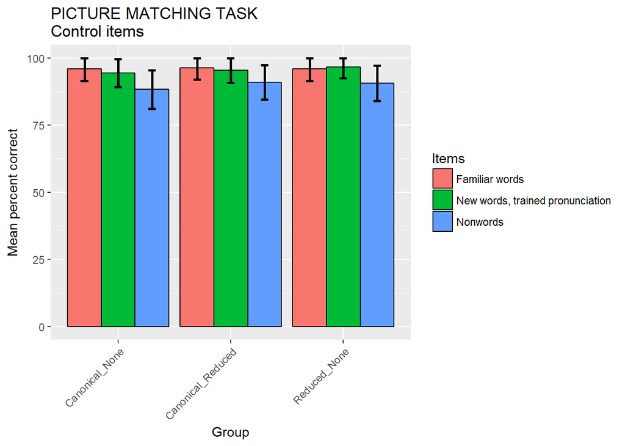

```r
##Calculating standard deviation and standard error to the mean:
control_sd <- aggregate(correct~pronunciation+group, exp1_controlTrials, FUN="sd")
control_sd$sem<- control_sd$correct/sqrt(20) #there are 20 subjects in each group
control_means$sd<-control_sd$correct
control_means$sem<-control_sd$sem


##multiply by 100 to get on a more readable % scale
control_means$correct<-control_means$correct*100
control_means$sd<-control_means$sd*100
control_means$sem<-control_means$sem*100

##if mean + sem>100, make it 100:
control_means$ymin <- control_means$correct - control_means$sem
control_means$ymax <- control_means$correct + control_means$sem
control_means$ymax[control_means$ymax > 100]<-100

##Code for the plot:

control.plot<-ggplot(control_means, aes(x=group, y=correct))+
  geom_bar(stat="identity", position="dodge", aes(fill=pronunciation), color="black")+
  geom_errorbar(aes(ymin=ymin, ymax=ymax, shape=pronunciation), width=.2,size=1, position=position_dodge(.9))+
  theme(axis.text.x=element_text(angle=45,hjust = 1))+
  ylab("Mean percent correct")+
  xlab("Group")+
  labs(title= "PICTURE MATCHING TASK\nControl items ",fill="Items")
control.plot
```

Results on control trials were consistent with our intuitions: high accuracy on all of them. Nonwords trials appeared a little harder than the others, but the stimuli was built such that the mispronunciation would be subtle (only one phoneme differed from the original word, e.g. “abron” for “apron”) and required the subjects’ full attention.

## ACCURACY ANALYSIS: CRITICAL TRIALS.

The critical trials are trials where the canonical pronunciation was presented.  
(These trials are subsetted in “exp1_canonical”)

What type of data do we have here?  
- each subject has 32 trials of critical words, some they learned with a spelling (canonical or variant)  
- in other words the measure is repeated within subjects  
- 2/3 of subjects were exposed to no ortho for some words  
- 2/3 to canon ortho  
- 2/3 to variant ortho

### Main effect of spelling?

Mean accuracy for the critical items for each spelling learned

#### Mean

```r
main_spelling.learned<-aggregate(correct~spelling.learned, exp1_canonical, FUN="mean")
main_spelling.learned
```

```
##   spelling.learned correct
## 1        canonical    0.38
## 2             none    0.63
## 3          reduced    0.71
```

#### Plot:

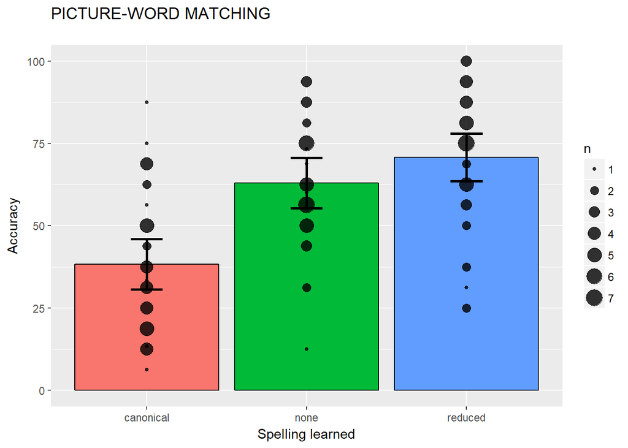

#### Analysis for the main effect of Spelling

Model with spelling.learned as a fixed factor

```r
spell.mod1<-glmer(correct~spelling.learned+(1|ID)+(1|item), data=exp1_canonical, family="binomial")
summary(spell.mod1)
```

```
## Generalized linear mixed model fit by maximum likelihood (Laplace
##   Approximation) [glmerMod]
##  Family: binomial  ( logit )
## Formula: correct ~ spelling.learned + (1 | ID) + (1 | item)
##    Data: exp1_canonical
##
##      AIC      BIC   logLik deviance df.resid
##     2093     2121    -1041     2083     1911
##
## Scaled residuals:
##    Min     1Q Median     3Q    Max
## -4.306 -0.647  0.270  0.614  5.966
##
## Random effects:
##  Groups Name        Variance Std.Dev.
##  ID     (Intercept) 0.937    0.968
##  item   (Intercept) 1.193    1.092
## Number of obs: 1916, groups:  ID, 60; item, 32
##
## Fixed effects:
##                         Estimate Std. Error z value Pr(>|z|)
## (Intercept)               -0.509      0.296   -1.72    0.085 .
## spelling.learnednone       1.260      0.222    5.68  1.4e-08 ***
## spelling.learnedreduced    1.594      0.341    4.67  3.0e-06 ***
## ---
## Signif. codes:  0 '***' 0.001 '**' 0.01 '*' 0.05 '.' 0.1 ' ' 1
##
## Correlation of Fixed Effects:
##              (Intr) spllng.lrndn
## spllng.lrndn -0.551
## spllng.lrndr -0.576  0.786
```

Model without fixed factor

```r
##base model
spell.mod0<-glmer(correct~(1|ID)+(1|item), data=exp1_canonical, family="binomial")
summary(spell.mod0)
```

```
## Generalized linear mixed model fit by maximum likelihood (Laplace
##   Approximation) [glmerMod]
##  Family: binomial  ( logit )
## Formula: correct ~ (1 | ID) + (1 | item)
##    Data: exp1_canonical
##
##      AIC      BIC   logLik deviance df.resid
##     2120     2136    -1057     2114     1913
##
## Scaled residuals:
##    Min     1Q Median     3Q    Max
## -5.247 -0.648  0.263  0.626  5.377
##
## Random effects:
##  Groups Name        Variance Std.Dev.
##  ID     (Intercept) 1.39     1.18
##  item   (Intercept) 1.39     1.18
## Number of obs: 1916, groups:  ID, 60; item, 32
##
## Fixed effects:
##             Estimate Std. Error z value Pr(>|z|)
## (Intercept)    0.456      0.265    1.72    0.085 .
## ---
## Signif. codes:  0 '***' 0.001 '**' 0.01 '*' 0.05 '.' 0.1 ' ' 1
```

Comparing the two

```r
##Likelihood test
anova(spell.mod0,spell.mod1)
```

```
## Data: exp1_canonical
## Models:
## spell.mod0: correct ~ (1 | ID) + (1 | item)
## spell.mod1: correct ~ spelling.learned + (1 | ID) + (1 | item)
##            Df  AIC  BIC logLik deviance Chisq Chi Df Pr(>Chisq)
## spell.mod0  3 2120 2136  -1057     2114
## spell.mod1  5 2093 2121  -1041     2083  30.9      2      2e-07 ***
## ---
## Signif. codes:  0 '***' 0.001 '**' 0.01 '*' 0.05 '.' 0.1 ' ' 1
```

Relevel the first model (i.e. change reference level) to get all the comparisons:

```r
##relevel to get all the comparisons between spellings:
spell_relevel<-within(exp1_canonical, spelling.learned <- relevel(spelling.learned, ref = 3))

spell.mod1_rlvl<-glmer(correct~spelling.learned+(1|ID)+(1|item), data=spell_relevel, family="binomial")
summary(spell.mod1_rlvl)
```

```
## Generalized linear mixed model fit by maximum likelihood (Laplace
##   Approximation) [glmerMod]
##  Family: binomial  ( logit )
## Formula: correct ~ spelling.learned + (1 | ID) + (1 | item)
##    Data: spell_relevel
##
##      AIC      BIC   logLik deviance df.resid
##     2093     2121    -1041     2083     1911
##
## Scaled residuals:
##    Min     1Q Median     3Q    Max
## -4.306 -0.647  0.270  0.614  5.966
##
## Random effects:
##  Groups Name        Variance Std.Dev.
##  ID     (Intercept) 0.937    0.968
##  item   (Intercept) 1.193    1.092
## Number of obs: 1916, groups:  ID, 60; item, 32
##
## Fixed effects:
##                           Estimate Std. Error z value Pr(>|z|)
## (Intercept)                  0.751      0.254    2.96   0.0031 **
## spelling.learnedcanonical   -1.260      0.222   -5.68  1.4e-08 ***
## spelling.learnedreduced      0.333      0.216    1.54   0.1230
## ---
## Signif. codes:  0 '***' 0.001 '**' 0.01 '*' 0.05 '.' 0.1 ' ' 1
##
## Correlation of Fixed Effects:
##              (Intr) spllng.lrndc
## spllng.lrndc -0.232
## spllng.lrndr -0.214 -0.213
```

### Direct test of hypothesis: accuracy by spelling.learned within the Canonical_Reduced group

This is a direct test of our hypothesis since participants in this group leanred half the words with a canonical spelling and half with a reduced spelling.  
A difference in accuracy based on spelling learned would indicate an effect of orthography on the perception of canonical pronunciations of words.

#### Means:

```
##   spelling.learned correct
## 1        canonical    0.46
## 2          reduced    0.64
```

#### Plot:

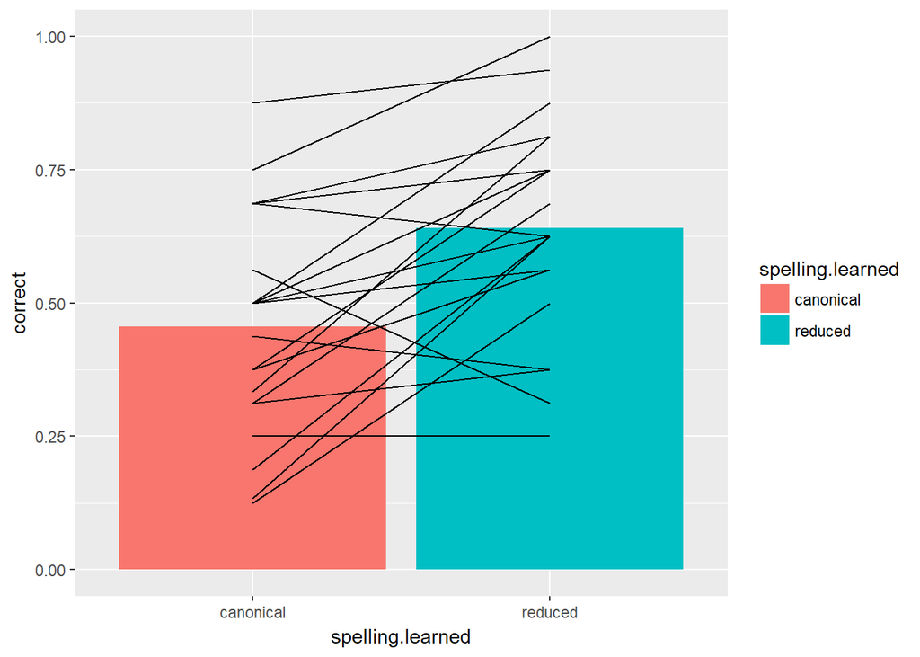

#### Analysis of the effect of spelling within the Canonical_Reduced group.

Model with spelling.learned as a fixed factor:

```
## Generalized linear mixed model fit by maximum likelihood (Laplace
##   Approximation) [glmerMod]
##  Family: binomial  ( logit )
## Formula: correct ~ spelling.learned + (1 | ID) + (1 | item)
##    Data: CR_criticalTrials
##
##      AIC      BIC   logLik deviance df.resid
##      772      789     -382      764      634
##
## Scaled residuals:
##    Min     1Q Median     3Q    Max
## -3.165 -0.728  0.294  0.680  2.825
##
## Random effects:
##  Groups Name        Variance Std.Dev.
##  item   (Intercept) 0.989    0.994
##  ID     (Intercept) 0.805    0.897
## Number of obs: 638, groups:  item, 32; ID, 20
##
## Fixed effects:
##                         Estimate Std. Error z value Pr(>|z|)
## (Intercept)               -0.220      0.345   -0.64     0.52
## spelling.learnedreduced    1.026      0.401    2.56     0.01 *
## ---
## Signif. codes:  0 '***' 0.001 '**' 0.01 '*' 0.05 '.' 0.1 ' ' 1
##
## Correlation of Fixed Effects:
##             (Intr)
## spllng.lrnd -0.571
```

Model without fixed factor:

```r
CR.mod0<-glmer(correct ~ (1|ID) + (1|item), CR_criticalTrials, family = "binomial")
```

Comparing the two:

```r
anova(CR.mod1, CR.mod0)
```

```
## Data: CR_criticalTrials
## Models:
## CR.mod0: correct ~ (1 | ID) + (1 | item)
## CR.mod1: correct ~ spelling.learned + (1 | ID) + (1 | item)
##         Df AIC BIC logLik deviance Chisq Chi Df Pr(>Chisq)
## CR.mod0  3 776 789   -385      770
## CR.mod1  4 772 789   -382      764   6.1      1      0.014 *
## ---
## Signif. codes:  0 '***' 0.001 '**' 0.01 '*' 0.05 '.' 0.1 ' ' 1
```

### Mean accuracy on the no spelling items in the Canonical_none and Reduced_none groups

Here we are testing whether the items that were not learned with any accompanying spelling inherited the properties of the items learned with a spelling. In other words we’re looking whether there were generalization.

#### Means:

```r
#subset of the "no spelling" trias in group Canonical_none and Reduced_None
CNRN_criticalTrials <-exp1_canonical[exp1_canonical$group %in% c("Canonical_None", "Reduced_None"),]
CNRN_noSpellingTrials <- CNRN_criticalTrials[CNRN_criticalTrials$spelling.learned %in% c("none"),]
#summary(CNRN_noSpellingTrials)

#means
CNRN_none.means <- aggregate(correct ~ group, CNRN_noSpellingTrials, FUN="mean")
CNRN_none.means
```

```
##            group correct
## 1 Canonical_None    0.52
## 2   Reduced_None    0.74
```

#### Plot:

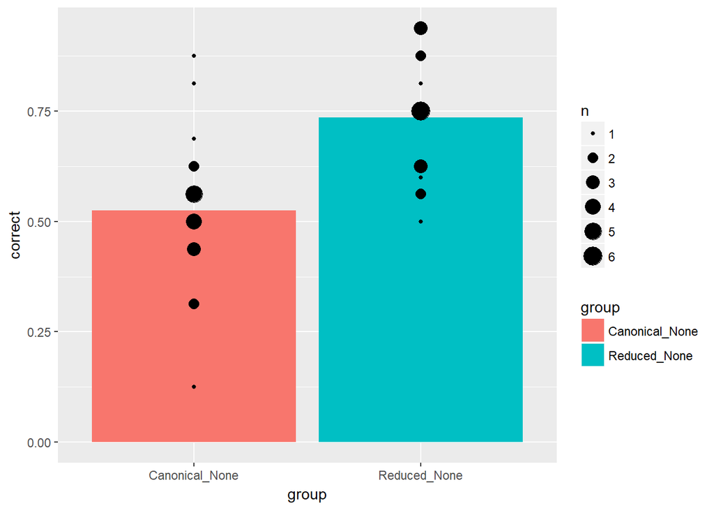

#### Analysis of difference on the no spelling items between Canonical_None and Reduced_None groups.

Model with group as a fixed factor:

```
## Generalized linear mixed model fit by maximum likelihood (Laplace
##   Approximation) [glmerMod]
##  Family: binomial  ( logit )
## Formula: correct ~ group + (1 | ID) + (1 | item)
##    Data: CNRN_noSpellingTrials
##
##      AIC      BIC   logLik deviance df.resid
##      716      734     -354      708      634
##
## Scaled residuals:
##    Min     1Q Median     3Q    Max
## -3.131 -0.657  0.336  0.569  2.111
##
## Random effects:
##  Groups Name        Variance Std.Dev.
##  ID     (Intercept) 0.469    0.685
##  item   (Intercept) 1.625    1.275
## Number of obs: 638, groups:  ID, 40; item, 32
##
## Fixed effects:
##                   Estimate Std. Error z value Pr(>|z|)
## (Intercept)          0.167      0.378    0.44    0.658
## groupReduced_None    1.226      0.542    2.26    0.024 *
## ---
## Signif. codes:  0 '***' 0.001 '**' 0.01 '*' 0.05 '.' 0.1 ' ' 1
##
## Correlation of Fixed Effects:
##             (Intr)
## gropRdcd_Nn -0.695
```

Model without the fixed factor:

```r
CNRN_none.mod0<-glmer(correct ~ (1|ID) + (1|item), CNRN_noSpellingTrials, family="binomial")
summary(CNRN_none.mod0)
```

```
## Generalized linear mixed model fit by maximum likelihood (Laplace
##   Approximation) [glmerMod]
##  Family: binomial  ( logit )
## Formula: correct ~ (1 | ID) + (1 | item)
##    Data: CNRN_noSpellingTrials
##
##      AIC      BIC   logLik deviance df.resid
##      719      732     -356      713      635
##
## Scaled residuals:
##    Min     1Q Median     3Q    Max
## -3.470 -0.663  0.334  0.556  2.291
##
## Random effects:
##  Groups Name        Variance Std.Dev.
##  ID     (Intercept) 0.499    0.707
##  item   (Intercept) 1.915    1.384
## Number of obs: 638, groups:  ID, 40; item, 32
##
## Fixed effects:
##             Estimate Std. Error z value Pr(>|z|)
## (Intercept)    0.779      0.289    2.69   0.0071 **
## ---
## Signif. codes:  0 '***' 0.001 '**' 0.01 '*' 0.05 '.' 0.1 ' ' 1
```

Comparing the two:

```r
anova(CNRN_none.mod1, CNRN_none.mod0)
```

```
## Data: CNRN_noSpellingTrials
## Models:
## CNRN_none.mod0: correct ~ (1 | ID) + (1 | item)
## CNRN_none.mod1: correct ~ group + (1 | ID) + (1 | item)
##                Df AIC BIC logLik deviance Chisq Chi Df Pr(>Chisq)
## CNRN_none.mod0  3 719 732   -356      713
## CNRN_none.mod1  4 716 734   -354      708  4.84      1      0.028 *
## ---
## Signif. codes:  0 '***' 0.001 '**' 0.01 '*' 0.05 '.' 0.1 ' ' 1
```

### Interaction between learning context and accuracy?

Comparing the difference between the Canonical_None canonical spelling trials performance and Reduced_None reduced spelling trials performance to the difference between the Canonical_Reduced canonical spelling trials and reduced spelling trials.

To be able to do this analysis I created a new variable called “learning condition”.  
This variable has two levels: consistent or inconsistent.  
In Group 1 and 2, I call the learning “consistent” because the rules listeners had to learn were simple:  
- **Group 1: when a word has a spelling**  
-intervocalic flap is always spelled “tt” (bytto)  
-nasal flap is always spelled “nt” (sento)  
- **Group 2: when a word has a spelling**  
-intervocalic flap is always spelled “dd” (cluddee)  
-nasal flap is always spelled “nn” (trenner)

In **Group 3** I call the learning “inconsistent” because the rules were more complicated:  
- intervocalic flap is spelled “tt” or “dd”  
- nasal flap is spelled “nt” or “nt”

#### Means:

```
##   learning spelling.learned correct   sd   sem
## 1   simple        canonical    0.31 0.46 0.104
## 2  complex        canonical    0.46 0.50 0.112
## 3   simple          reduced    0.78 0.42 0.094
## 4  complex          reduced    0.64 0.48 0.107
```

#### Plot

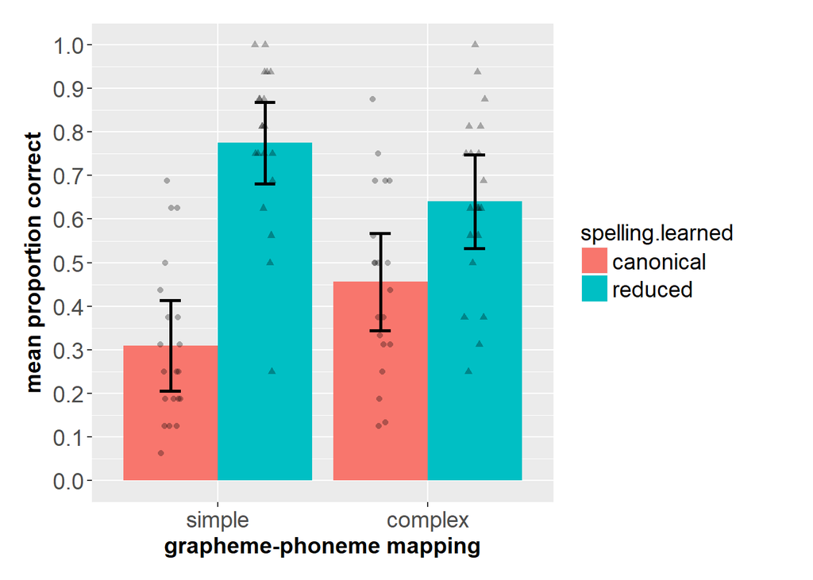

#### Analyses:

Model with interaction:

```r
learning.mod1 <- glmer(correct ~ learning/spelling.learned + (1|ID)+
                         (1|item),exp1_interaction, family="binomial")

summary(learning.mod1)
```

```
## Generalized linear mixed model fit by maximum likelihood (Laplace
##   Approximation) [glmerMod]
##  Family: binomial  ( logit )
## Formula: correct ~ learning/spelling.learned + (1 | ID) + (1 | item)
##    Data: exp1_interaction
##
##      AIC      BIC   logLik deviance df.resid
##     1404     1435     -696     1392     1272
##
## Scaled residuals:
##    Min     1Q Median     3Q    Max
## -4.431 -0.628  0.233  0.608  3.884
##
## Random effects:
##  Groups Name        Variance Std.Dev.
##  ID     (Intercept) 0.897    0.947
##  item   (Intercept) 1.040    1.020
## Number of obs: 1278, groups:  ID, 60; item, 32
##
## Fixed effects:
##                                         Estimate Std. Error z value
## (Intercept)                               -1.078      0.361   -2.99
## learningcomplex                            0.853      0.356    2.39
## learningsimple:spelling.learnedreduced     2.779      0.520    5.34
## learningcomplex:spelling.learnedreduced    1.028      0.408    2.52
##                                         Pr(>|z|)
## (Intercept)                               0.0028 **
## learningcomplex                           0.0167 *
## learningsimple:spelling.learnedreduced   9.1e-08 ***
## learningcomplex:spelling.learnedreduced   0.0117 *
## ---
## Signif. codes:  0 '***' 0.001 '**' 0.01 '*' 0.05 '.' 0.1 ' ' 1
##
## Correlation of Fixed Effects:
##             (Intr) lrnngc lrnngs:.
## lernngcmplx -0.506
## lrnngsmpl:. -0.699  0.356
## lrnngcmpl:. -0.446 -0.113  0.624
```

Model without interaction:

```r
learning.mod0 <-glmer(correct~learning+spelling.learned+(1|ID)+(1|item), data=exp1_interaction, family="binomial")
summary(learning.mod0)
```

```
## Generalized linear mixed model fit by maximum likelihood (Laplace
##   Approximation) [glmerMod]
##  Family: binomial  ( logit )
## Formula: correct ~ learning + spelling.learned + (1 | ID) + (1 | item)
##    Data: exp1_interaction
##
##      AIC      BIC   logLik deviance df.resid
##     1419     1445     -705     1409     1273
##
## Scaled residuals:
##    Min     1Q Median     3Q    Max
## -3.992 -0.642  0.239  0.597  3.587
##
## Random effects:
##  Groups Name        Variance Std.Dev.
##  ID     (Intercept) 1.16     1.08
##  item   (Intercept) 1.03     1.02
## Number of obs: 1278, groups:  ID, 60; item, 32
##
## Fixed effects:
##                         Estimate Std. Error z value Pr(>|z|)
## (Intercept)              -0.3901     0.3350   -1.16  0.24424
## learningcomplex           0.0073     0.3269    0.02  0.98217
## spelling.learnedreduced   1.3663     0.4017    3.40  0.00067 ***
## ---
## Signif. codes:  0 '***' 0.001 '**' 0.01 '*' 0.05 '.' 0.1 ' ' 1
##
## Correlation of Fixed Effects:
##             (Intr) lrnngc
## lernngcmplx -0.365
## spllng.lrnd -0.596  0.004
```

Comparing the two:

```r
anova(learning.mod0, learning.mod1)
```

```
## Data: exp1_interaction
## Models:
## learning.mod0: correct ~ learning + spelling.learned + (1 | ID) + (1 | item)
## learning.mod1: correct ~ learning/spelling.learned + (1 | ID) + (1 | item)
##               Df  AIC  BIC logLik deviance Chisq Chi Df Pr(>Chisq)
## learning.mod0  5 1419 1445   -705     1409
## learning.mod1  6 1404 1435   -696     1392    17      1   0.000037 ***
## ---
## Signif. codes:  0 '***' 0.001 '**' 0.01 '*' 0.05 '.' 0.1 ' ' 1
```